# Group Project

Kamal, Ask, Min, Adrian

7/30/2020

## BACKGROUND

#### Between 2003 and 2010, Nepal implemented two periodic plans, tenth and eleventh respectively which were known as poverty reduction strategies. The objective of the tenth plan (2003-2007) was to achieve broad based and poverty alleviation oriented economic growth and bring some positive change through social inclusion and targeted programs. It focused on some targeted programs self employment through social mobilization, among the poor, women’s awareness, microcredit to the poor people, support poor people from poverty alleviation fund. On the other hand, the eleventh plan focused on inclusive development to increase the access of the economically deprive social group women, persons with disability, infrastructure development such rural roads, irrigation projects, income oriented skill development and soft loan to the target groups.This study therefore sought to assess the impact of these efforts on food security attainment among households.

## DATA

#### Due to lake of treatment and control group in data set, we used the pool cross sectional data of Nepal Living Standard Survey between the period 2003 and 2010. The survey was conducted by Central Bureau of Statistics in the stated period. The sample was selected from two stage random sampling procedure. In first place, 14 ecological stratums were selected and 500 sampling units were selected from 14 ecological belt. Total sample sizes of 4000 and 6000 in 2003/04 and 2010/11 respectively were randomly selected and out of these, 5988 household were successfully interviewed. In this study we used log of per capita food consumption, household size ( by year and belts) as our key variables. Geographically Nepal is divided in three belts namely; Terai-which is a low land region containing some hill ranges; Hill-which is a mountainous region that does not generally contain snow; and mountain-which is the Himalayan region that generally contains snow. 2010 per capital consumption and per capita household expenditure were adjusted in 2003 price by consumer price index. Summary of data and sample plote are prsented below.

```
##              group1    n    mean   sd     min     max
## hhsize1        2003 3912    5.18 2.51    1.00   32.00
## hhsize2        2010 5988    4.76 2.31    1.00   20.00
## ln_pc_fcons1   2003 3912    8.86 0.50    7.13   10.83
## ln_pc_fcons2   2010 5986    9.27 0.52    6.97   11.69
## belt1          2003 3912    2.32 0.64    1.00    3.00
## belt2          2010 5988    2.33 0.60    1.00    3.00
## urbrur1        2003 3912    1.70 0.46    1.00    2.00
## urbrur2        2010 5988    1.65 0.48    1.00    2.00
## year1          2003 3912 2003.00 0.00 2003.00 2003.00
## year2          2010 5988 2010.00 0.00 2010.00 2010.00
```

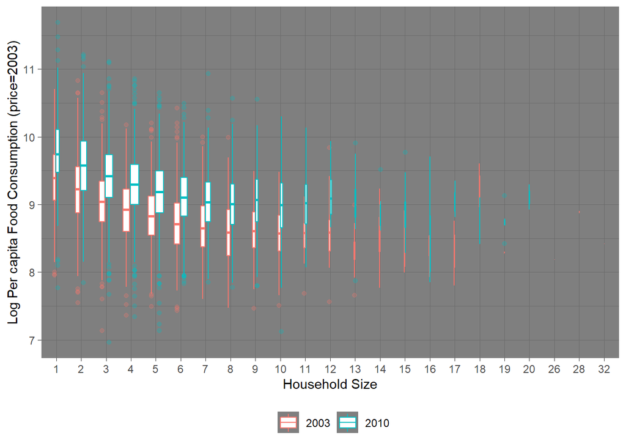